# ML STUDENT COMPETITION II: Neural Networks

David Galera

```python
from google.colab import drive
drive.mount('/content/drive')
```

```python
#!pip install scikeras
```

```python
import pandas as pd
import numpy as np
import matplotlib.pyplot as plt
import seaborn as sns
from sklearn.utils import shuffle
from tensorflow.keras.utils import to_categorical
import tensorflow as tf
from tensorflow.keras.layers.experimental.preprocessing import Normalization
from tensorflow import keras
from tensorflow.keras import layers
from tensorflow.keras.callbacks import EarlyStopping
from sklearn.model_selection import cross_val_score, GridSearchCV, KFold, RandomizedSearchCV, train_test_split, GridSearchCV
from sklearn.preprocessing import LabelEncoder, StandardScaler, MinMaxScaler, Normalizer, MaxAbsScaler, RobustScaler
from tensorflow.keras.layers import BatchNormalization
#from scikeras.wrappers import KerasClassifier
from tensorflow.keras.wrappers.scikit_learn import KerasClassifier
```

```python
train = pd.read_csv('/content/drive/MyDrive/kaggle_nn/train.csv')
validate = pd.read_csv('/content/drive/MyDrive/kaggle_nn/validate.csv')
```

```python
train.head()
```

|  | id | f_00 | f_01 | f_02 | f_03 | f_04 | f_05 | f_06 | f_07 | f_08 | ... | f_22 | f_23 | f_24 | f_25 | f_26 | f_27 | f_28 | f_29 | f_30 | target |
| --- | --- | --- | --- | --- | --- | --- | --- | --- | --- | --- | --- | --- | --- | --- | --- | --- | --- | --- | --- | --- | --- |
| 0 | 493553 | 0.315471 | -0.183690 | 0.664383 | -1.186794 | 0.665098 | 0.946208 | 0.729857 | 0 | 4 | ... | -1.409039 | 3.645067 | 0.233039 | -3.754846 | -1.061733 | BDBBCACIBB | 20.308715 | 1 | 0 | 0 |
| 1 | 237346 | -1.286392 | 1.780592 | 0.576698 | -2.690658 | 1.321997 | -0.675894 | 0.371070 | 3 | 0 | ... | 3.087653 | 0.494209 | 3.210875 | -0.666457 | 0.123854 | ACBDCBCADA | -449.291063 | 1 | 0 | 0 |
| 2 | 37368 | -0.290303 | -0.485907 | 0.808350 | -0.156288 | 1.083632 | -1.129914 | 0.767396 | 3 | 1 | ... | 2.084169 | -4.782668 | -1.671375 | 2.774382 | 2.273130 | AABBABCLAF | -86.206118 | 0 | 1 | 1 |
| 3 | 665220 | 1.243590 | 0.035112 | -1.013236 | 0.854267 | 0.019192 | 0.597892 | -2.020416 | 2 | 0 | ... | -0.701691 | -2.769142 | -6.534231 | -0.557677 | -0.429972 | ADBBABEEBA | -30.157403 | 0 | 2 | 1 |
| 4 | 41499 | 0.702716 | 0.817044 | -0.064907 | -1.045483 | 0.718374 | 0.164451 | -0.936620 | 1 | 2 | ... | 1.154162 | -1.931443 | 2.325042 | 2.143811 | -1.039599 | ABBBBBCMBB | 296.484562 | 0 | 2 | 1 |

5 rows × 33 columns

```python
train = shuffle(train, random_state=3)
print(train.shape)
print(train.dtypes)
train.drop('id',axis=1,inplace=True)
train['target'].value_counts()
```

```
(810000, 33)
id          int64
f_00      float64
f_01      float64
f_02      float64
f_03      float64
f_04      float64
f_05      float64
f_06      float64
f_07        int64
f_08        int64
f_09        int64
f_10        int64
f_11        int64
f_12        int64
f_13        int64
f_14        int64
f_15        int64
f_16        int64
f_17        int64
f_18        int64
f_19      float64
f_20      float64
f_21      float64
f_22      float64
f_23      float64
f_24      float64
f_25      float64
f_26      float64
f_27       object
f_28      float64
f_29        int64
f_30        int64
target      int64
dtype: object
```

```
0    415945
1    394055
Name: target, dtype: int64
```

```python
print('Percentatge de targets')
train.target.value_counts(normalize=True).round(2)
```

```
Percentatge de targets
```

```
0    0.51
1    0.49
Name: target, dtype: float64
```

# Feature engineering: Manipulació i tractament de dades

Aplicarem les transformacions a les dades als **conjunts d'entrenament i validació al mateix temps**, per tenir el mateix format d'entrada a la xarxa neuronal en els 2 conjunts.

## Tractament de les variables de tipus *int*:

```python
categorical = [f for f in train.columns if ((train[f].dtype == 'int64') & (f != 'target'))]
print(categorical)
```

```
['f_07', 'f_08', 'f_09', 'f_10', 'f_11', 'f_12', 'f_13', 'f_14', 'f_15', 'f_16', 'f_17', 'f_18', 'f_29', 'f_30']
```

```python
#categorical=['f_07','f_08','f_09','f_10','f_11','f_12','f_13','f_14','f_15','f_16','f_17','f_18','f_29','f_30']
```

```python
for i in categorical:
  print(i,sorted(train[i].unique()))
```

```
f_07 [0, 1, 2, 3, 4, 5, 6, 7, 8, 9, 10, 11, 12, 13, 14, 15]
f_08 [0, 1, 2, 3, 4, 5, 6, 7, 8, 9, 10, 11, 12, 13, 14, 16]
f_09 [0, 1, 2, 3, 4, 5, 6, 7, 8, 9, 10, 11, 12, 13, 14]
f_10 [0, 1, 2, 3, 4, 5, 6, 7, 8, 9, 10, 11, 12, 13, 14]
f_11 [0, 1, 2, 3, 4, 5, 6, 7, 8, 9, 10, 11, 12, 13]
f_12 [0, 1, 2, 3, 4, 5, 6, 7, 8, 9, 10, 11, 12, 13, 14, 16]
f_13 [0, 1, 2, 3, 4, 5, 6, 7, 8, 9, 10, 11, 12]
f_14 [0, 1, 2, 3, 4, 5, 6, 7, 8, 9, 10, 11, 12, 14]
f_15 [0, 1, 2, 3, 4, 5, 6, 7, 8, 9, 10, 11, 12, 13, 14]
f_16 [0, 1, 2, 3, 4, 5, 6, 7, 8, 9, 10, 11, 12, 13, 14, 15]
f_17 [0, 1, 2, 3, 4, 5, 6, 7, 8, 9, 10, 11, 12]
f_18 [0, 1, 2, 3, 4, 5, 6, 7, 8, 9, 10, 11, 12, 13]
f_29 [0, 1]
f_30 [0, 1, 2]
```

```python
for i in categorical:
  print(i,sorted(validate[i].unique()))
```

```
f_07 [0, 1, 2, 3, 4, 5, 6, 7, 8, 9, 10, 11, 12, 13, 15]
f_08 [0, 1, 2, 3, 4, 5, 6, 7, 8, 9, 10, 11, 12, 13, 14]
f_09 [0, 1, 2, 3, 4, 5, 6, 7, 8, 9, 10, 11, 12, 13]
f_10 [0, 1, 2, 3, 4, 5, 6, 7, 8, 9, 10, 11, 12]
f_11 [0, 1, 2, 3, 4, 5, 6, 7, 8, 9, 10, 11, 13]
f_12 [0, 1, 2, 3, 4, 5, 6, 7, 8, 9, 10, 11, 12, 14]
f_13 [0, 1, 2, 3, 4, 5, 6, 7, 8, 9, 10, 11]
f_14 [0, 1, 2, 3, 4, 5, 6, 7, 8, 9, 10, 11]
f_15 [0, 1, 2, 3, 4, 5, 6, 7, 8, 9, 10, 11]
f_16 [0, 1, 2, 3, 4, 5, 6, 7, 8, 9, 10, 11]
f_17 [0, 1, 2, 3, 4, 5, 6, 7, 8, 9, 10, 11, 14]
f_18 [0, 1, 2, 3, 4, 5, 6, 7, 8, 9, 10, 11, 12]
f_29 [0, 1]
f_30 [0, 1, 2]
```

Apliquem One-Hot encoding i les transformem a array:

```python
X_trainval=pd.concat([train.drop(['f_27','target'],axis=1),validate.drop(['id','f_27'],axis=1)])#Horizontal Stack dels 2 dataframes
X_cat=X_trainval[categorical]
X_cat=pd.get_dummies(X_cat,columns=categorical,drop_first=True).values
```

```python
X_trainval.shape
```

```
(900000, 30)
```

```python
X_cat.shape #169 columnes
```

```
(900000, 169)
```

## Tractament de les variables tipus *float*:

```python
numeric = [f for f in train.columns if train[f].dtype == 'float64']
print(numeric)
```

```
['f_00', 'f_01', 'f_02', 'f_03', 'f_04', 'f_05', 'f_06', 'f_19', 'f_20', 'f_21', 'f_22', 'f_23', 'f_24', 'f_25', 'f_26', 'f_28']
```

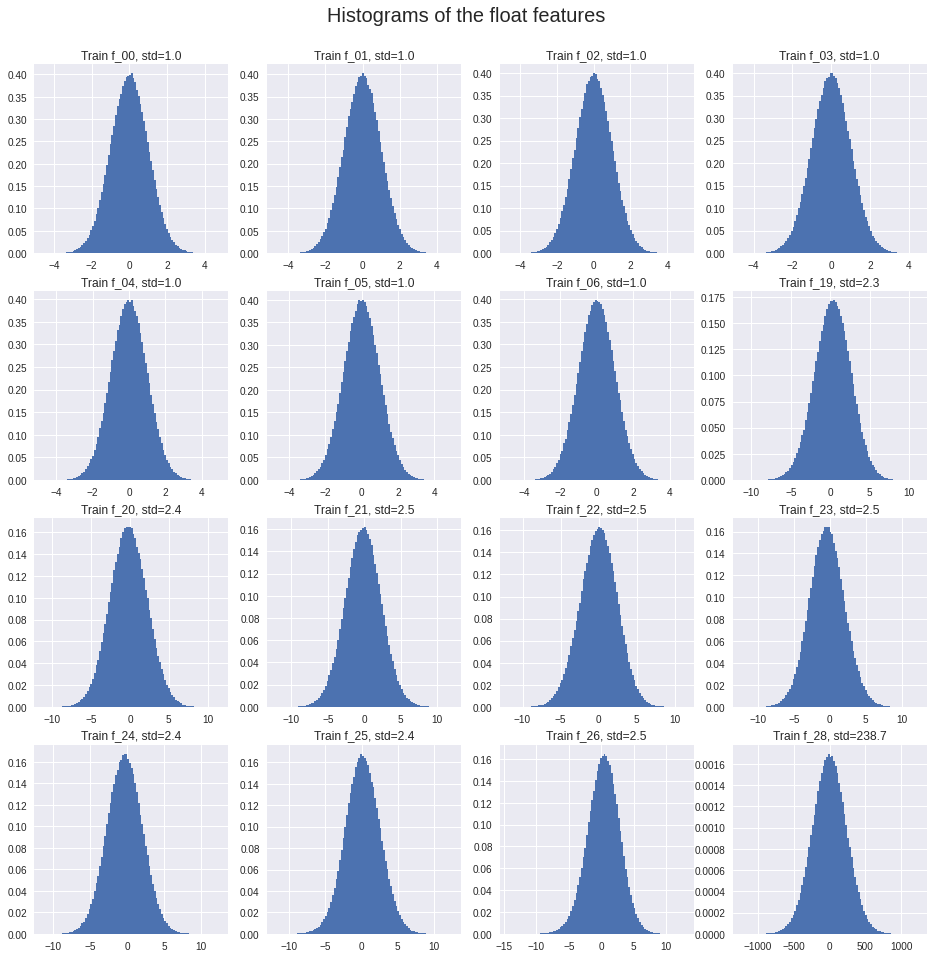

```
var:  f_00 1.0
mean: f_00 0.0
var:  f_01 1.0
mean: f_01 0.0
var:  f_02 1.0
mean: f_02 0.0
var:  f_03 1.0
mean: f_03 -0.0
var:  f_04 1.0
mean: f_04 -0.0
var:  f_05 1.0
mean: f_05 0.0
var:  f_06 1.0
mean: f_06 -0.0
var:  f_19 5.36
mean: f_19 0.31
var:  f_20 5.76
mean: f_20 -0.18
var:  f_21 6.17
mean: f_21 -0.16
var:  f_22 6.0
mean: f_22 -0.01
var:  f_23 6.02
mean: f_23 -0.37
var:  f_24 5.7
mean: f_24 -0.34
var:  f_25 5.84
mean: f_25 0.18
var:  f_26 6.13
mean: f_26 0.36
var:  f_28 56994.8
mean: f_28 -0.45
```

```python
plt.style.use('seaborn')
fig, axs = plt.subplots(4, 4, figsize=(16, 16))
for f, ax in zip(numeric, axs.ravel()):
    ax.hist(train[f], density=True, bins=100)
    ax.set_title(f'Train {f}, std={train[f].std():.1f}')
plt.suptitle('Histograms of the float features', y=0.93, fontsize=20)
plt.show()
for i in numeric:
  print('var: ',i,train[i].var().round(2))
  print('mean:',i,train[i].mean().round(2))
```

Observen que les variables de la *f_00* a la *f_06* estàn estandaritzades, però de la **f_19 a la f_28 tenen mitjana propera a 0 i variança superior a 1.**

Les estandaritzem:

```python
X_num=X_trainval[numeric].values #array
sc = StandardScaler()#Scaler
X_num = sc.fit_transform(X_num)
print(X_num.shape)
```

```
(900000, 16)
```

## Tractament de la variable f_27 tipus *object*:

```python
print(train.f_27.head())
print(train.f_27.value_counts())
```

```
706419    BABCEBBDDC
507964    ACBDABBDDE
302647    ACBDABCKEC
243186    ABAACAGMAB
283830    BEBCBBECEH
Name: f_27, dtype: object
BCBBBBCLBC    12
BBBBBBCJBC    11
BBBBBABLCB    10
BBBBBBDPCB    10
ACBBBACFCC     9
              ..
ABBDCABHDD     1
AAADBBGLFA     1
AEACABBFHC     1
BCBCEAARBC     1
BBADCABBFA     1
Name: f_27, Length: 678113, dtype: int64
```

La variable està composta per seqüències de 10 lletres. La seqüencia més freqüent només es repeteix 12 vegades i el 83.7% de seqüencies són úniques.

Analitzem per cada posició i valor de la cadena quin és el valor promig del seu target:

```python
for pos in range(10):
    train_group = train.groupby(train.f_27.str.get(pos))
    print(f"Position -> {pos}")
    display(pd.DataFrame({"size":train_group.target.size(),"mean_target":train_group.target.mean().round(2)}))
```

```
Position -> 0
```

| f_27 | size | mean_target |
| --- | --- | --- |
| A | 406235 | 0.54 |
| B | 403765 | 0.44 |

```
Position -> 1
```

| f_27 | size | mean_target |
| --- | --- | --- |
| A | 130291 | 0.58 |
| B | 220669 | 0.48 |
| C | 203184 | 0.49 |
| D | 134634 | 0.45 |
| E | 71022 | 0.43 |
| F | 31862 | 0.42 |
| G | 12387 | 0.41 |
| H | 4209 | 0.40 |
| I | 1248 | 0.39 |
| J | 364 | 0.40 |
| K | 104 | 0.37 |
| L | 22 | 0.32 |
| M | 2 | 0.50 |
| N | 2 | 1.00 |

```
Position -> 2
```

| f_27 | size | mean_target |
| --- | --- | --- |
| A | 268058 | 0.53 |
| B | 541942 | 0.46 |

```
Position -> 3
```

| f_27 | size | mean_target |
| --- | --- | --- |
| A | 144675 | 0.57 |
| B | 213376 | 0.48 |
| C | 189144 | 0.48 |
| D | 129174 | 0.45 |
| E | 73684 | 0.43 |
| F | 35523 | 0.44 |
| G | 15432 | 0.45 |
| H | 5811 | 0.47 |
| I | 2139 | 0.48 |
| J | 699 | 0.51 |
| K | 227 | 0.58 |
| L | 75 | 0.68 |
| M | 31 | 0.61 |
| N | 7 | 0.71 |
| O | 3 | 1.00 |

```
Position -> 4
```

| f_27 | size | mean_target |
| --- | --- | --- |
| A | 233774 | 0.48 |
| B | 255931 | 0.45 |
| C | 176872 | 0.49 |
| D | 89076 | 0.53 |
| E | 35020 | 0.57 |
| F | 12713 | 0.64 |
| G | 4509 | 0.72 |
| H | 1492 | 0.76 |
| I | 438 | 0.78 |
| J | 136 | 0.82 |
| K | 27 | 0.89 |
| L | 9 | 1.00 |
| M | 2 | 1.00 |
| O | 1 | 1.00 |

```
Position -> 5
```

| f_27 | size | mean_target |
| --- | --- | --- |
| A | 431185 | 0.47 |
| B | 378815 | 0.51 |

```
Position -> 6
```

| f_27 | size | mean_target |
| --- | --- | --- |
| A | 91397 | 0.58 |
| B | 180189 | 0.49 |
| C | 198101 | 0.49 |
| D | 155996 | 0.46 |
| E | 97014 | 0.45 |
| F | 50789 | 0.46 |
| G | 22786 | 0.47 |
| H | 8952 | 0.48 |
| I | 3311 | 0.49 |
| J | 1027 | 0.50 |
| K | 296 | 0.51 |
| L | 111 | 0.52 |
| M | 20 | 0.70 |
| N | 10 | 0.20 |
| O | 1 | 1.00 |

```
Position -> 7
```

| f_27 | size | mean_target |
| --- | --- | --- |
| A | 40519 | 0.48 |
| B | 41248 | 0.41 |
| C | 41252 | 0.41 |
| D | 41013 | 0.41 |
| E | 41314 | 0.42 |
| F | 41243 | 0.43 |
| G | 40981 | 0.44 |
| H | 41194 | 0.45 |
| I | 41224 | 0.46 |
| J | 41167 | 0.47 |
| K | 41198 | 0.48 |
| L | 41102 | 0.49 |
| M | 41302 | 0.51 |
| N | 41290 | 0.51 |
| O | 40781 | 0.53 |
| P | 40665 | 0.54 |
| Q | 40231 | 0.53 |
| R | 39239 | 0.55 |
| S | 37719 | 0.59 |
| T | 35318 | 0.64 |

```
Position -> 8
```

| f_27 | size | mean_target |
| --- | --- | --- |
| A | 143885 | 0.40 |
| B | 202368 | 0.45 |
| C | 192011 | 0.49 |
| D | 134319 | 0.52 |
| E | 76021 | 0.56 |
| F | 36650 | 0.60 |
| G | 15835 | 0.62 |
| H | 5868 | 0.65 |
| I | 2127 | 0.64 |
| J | 659 | 0.70 |
| K | 185 | 0.65 |
| L | 49 | 0.76 |
| M | 18 | 0.67 |
| N | 4 | 0.75 |
| O | 1 | 1.00 |

```
Position -> 9
```

| f_27 | size | mean_target |
| --- | --- | --- |
| A | 103427 | 0.36 |
| B | 188988 | 0.43 |
| C | 197182 | 0.49 |
| D | 149564 | 0.51 |
| E | 90183 | 0.57 |
| F | 46480 | 0.62 |
| G | 20936 | 0.65 |
| H | 8648 | 0.68 |
| I | 3083 | 0.72 |
| J | 1044 | 0.75 |
| K | 345 | 0.75 |
| L | 81 | 0.83 |
| M | 32 | 0.84 |
| N | 6 | 0.83 |
| O | 1 | 1.00 |

Aquí podem veure com la lletra que hi ha a cada posició de la cadena té relació amb el valor del target. Per tant és convenient aplicar **feature engineering** per separar cada posició de la cadena en una feature independent i aplicar One Hot encoding als caràcters per que la xarxa neuronal pugui aprendre d'aquesta informació:

```python
f_27=pd.concat([train.f_27,validate.f_27])
f_27_split = pd.DataFrame([list(i) for i in f_27.values])
f_27_split.columns = ["ch0","ch1","ch2","ch3","ch4","ch5","ch6","ch7","ch8","ch9"]
print(f_27_split.shape)
f_27_split.head()
```

```
(900000, 10)
```

|  | ch0 | ch1 | ch2 | ch3 | ch4 | ch5 | ch6 | ch7 | ch8 | ch9 |
| --- | --- | --- | --- | --- | --- | --- | --- | --- | --- | --- |
| 0 | B | A | B | C | E | B | B | D | D | C |
| 1 | A | C | B | D | A | B | B | D | D | E |
| 2 | A | C | B | D | A | B | C | K | E | C |
| 3 | A | B | A | A | C | A | G | M | A | B |
| 4 | B | E | B | C | B | B | E | C | E | H |

```python
f_27_dummy=pd.get_dummies(f_27_split,columns=f_27_split.columns,drop_first=True).values
print(f_27_dummy.shape)
f_27_dummy[0,:]
```

```
(900000, 104)
```

```
array([1, 0, 0, 0, 0, 0, 0, 0, 0, 0, 0, 0, 0, 0, 1, 0, 1, 0, 0, 0, 0, 0,
       0, 0, 0, 0, 0, 0, 0, 0, 0, 0, 1, 0, 0, 0, 0, 0, 0, 0, 0, 0, 1, 1,
       0, 0, 0, 0, 0, 0, 0, 0, 0, 0, 0, 0, 0, 0, 0, 1, 0, 0, 0, 0, 0, 0,
       0, 0, 0, 0, 0, 0, 0, 0, 0, 0, 0, 0, 1, 0, 0, 0, 0, 0, 0, 0, 0, 0,
       0, 0, 0, 1, 0, 0, 0, 0, 0, 0, 0, 0, 0, 0, 0, 0], dtype=uint8)
```

Buscant més possibles relacions entre la cadena de caràcters i el target, comprovem si el número únic de caràcters que hi ha a la cadena està relacionat amb el valor promig del target.

```python
f_27_unic_ch = train.f_27.apply(lambda x : len(set(x)))
group_train = train.groupby(f_27_unic_ch)
display(pd.DataFrame({"size":group_train.target.size(),"mean_target":group_train.target.mean().round(2)}))
```

| f_27 | size | mean_target |
| --- | --- | --- |
| 1 | 1 | 0.00 |
| 2 | 974 | 0.09 |
| 3 | 28864 | 0.09 |
| 4 | 190034 | 0.48 |
| 5 | 359805 | 0.49 |
| 6 | 198966 | 0.48 |
| 7 | 30282 | 0.91 |
| 8 | 1068 | 0.91 |
| 9 | 6 | 1.00 |

Aquí podem veure com hi ha una relació molt clara, com més caràcters únics hi ha a la cadena, més probabilitat que el target sigui 1. Afegim aquesta informació i apliquem One Hot Encoding:

```python
unic_ch=f_27.apply(lambda x : len(set(x)))
print(unic_ch.shape)
unic_ch_dummy=pd.get_dummies(unic_ch,drop_first=True).values
print(unic_ch_dummy.shape)
```

```
(900000,)
(900000, 8)
```

Concatenem les arrays de dades amb totes les transformacions realitzades:

```python
X_total=np.hstack((X_num, X_cat,f_27_dummy,unic_ch_dummy))
X_total.shape
```

```
(900000, 297)
```

Amb totes les variables transformades, separem els conjunts d'entrenament i validació:

```python
X_nn=X_total[:810000,:]
print(X_nn.shape)
X_validate=X_total[810000:,:]
print(X_validate.shape)
"Target"
y=train['target'].copy()
y=np.array(y)
```

```
(810000, 297)
(90000, 297)
```

# Neural network

Aqui he estat dissenyant i fent proves amb la xarxa neural:

Començant amb 1 hidden layer de 10 neurones i augmentant neurones i capes, així com ajustant el *learning rate*, la mida del *batch* i provant diferents funcions d'activació i optimitzadors. A la capa de sortida hi ha d'haver 1 neurona amb una funció d'activació *sigmoid* ja que la classificació es binaria.

```python
#Relu es la millor
np.random.seed(1)
def get_model(act_function):
    model = keras.Sequential()
    model.add(layers.Dense(50, activation='relu', input_shape = (X_nn.shape[1],)))
    model.add(layers.Dense(50, activation=act_function))
    model.add(layers.Dense(50, activation=act_function))
    model.add(layers.Dense(1, activation='sigmoid'))
    return model
activations = ['relu','sigmoid','tanh']
activation_results={}
for funct in activations:
    model =get_model(act_function=funct)
    opt = keras.optimizers.Adam(learning_rate=0.005)
    model.compile(optimizer=opt, loss='binary_crossentropy',metrics=['accuracy'])
    history = model.fit(X_nn, y, validation_split=0.1, epochs=40, batch_size=512, callbacks =EarlyStopping(monitor='val_loss',patience=5))#'val_acc'
    activation_results[funct] = history
```

```python
val_loss_per_funct={k:v.history['val_loss'] for k,v in activation_results.items()}
```

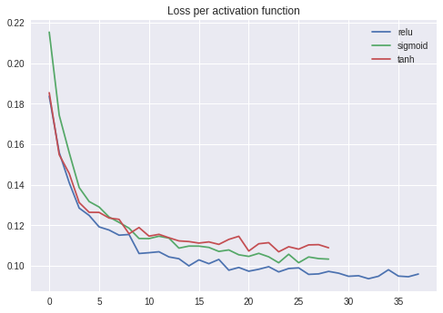

```python
plt.style.use('seaborn')
val_loss_curves=pd.DataFrame(dict([ (k,pd.Series(v)) for k,v in val_loss_per_funct.items() ]))
val_loss_curves.plot(title='Loss per activation function')
```

## Preliminar Neural network

```python
model = keras.Sequential()
model.add(layers.Dense(50, activation='relu',kernel_initializer='normal', input_shape = (X_nn.shape[1],)))
model.add(BatchNormalization())
model.add(layers.Dense(50, activation='relu',kernel_initializer='normal'))
model.add(BatchNormalization())
model.add(layers.Dense(50, activation='relu',kernel_initializer='normal'))
model.add(BatchNormalization())
model.add(layers.Dense(50, activation='relu',kernel_initializer='normal'))
model.add(BatchNormalization())
model.add(layers.Dense(50, activation='relu',kernel_initializer='normal'))
model.add(BatchNormalization())
model.add(layers.Dense(20, activation='relu',kernel_initializer='normal'))
model.add(BatchNormalization())
model.add(layers.Dense(1, activation='sigmoid'))

opt = keras.optimizers.Adam(learning_rate=0.03)
model.compile(optimizer=opt, loss='binary_crossentropy',metrics=['accuracy'])
```

```python
with tf.device('/GPU:0'):
    history1 = model.fit(X_nn, y, validation_split=0.1, batch_size=512, epochs=300, \
                        callbacks =EarlyStopping(monitor='val_loss',patience=100))
```

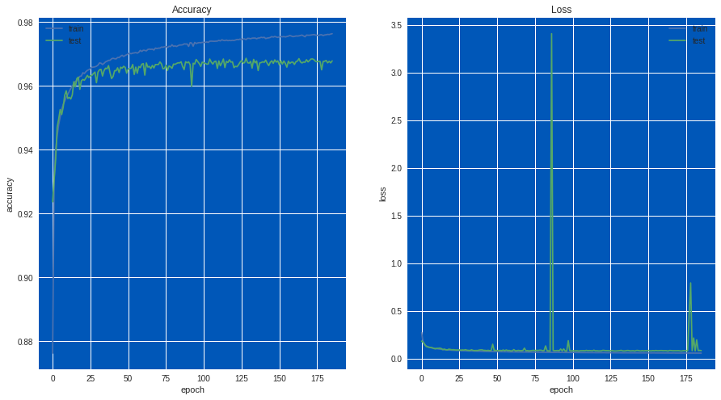

```python
plt.style.use('seaborn')
fig, (ax1, ax2) = plt.subplots(1,2,figsize=(15,8))

#Accuracy
ax1.plot(history1.history['accuracy'], label='train')
ax1.plot(history1.history['val_accuracy'], label='test')
ax1.set_xlabel('epoch')
ax1.set_ylabel('accuracy')
ax1.set_title('Accuracy')
ax1.legend()

#Loss
ax2.plot(history1.history['loss'], label='train')
ax2.plot(history1.history['val_loss'], label='test')
ax2.set_xlabel('epoch')
ax2.set_ylabel('loss')
ax2.set_title('Loss')
ax2.legend()
plt.show()
```

Després de fer proves i entrenar la xarxa neuronal durant vàries hores, el màxim **val_accuracy** que he aconseguit ha estat del **96.8%**

# Feature engineering: part 2

Amb l'objectiu de superar el 97% de **val_accuracy** tornem a revisar el dataset en busca d'informació extra que poguem introduïr a la xarxa neuronal.

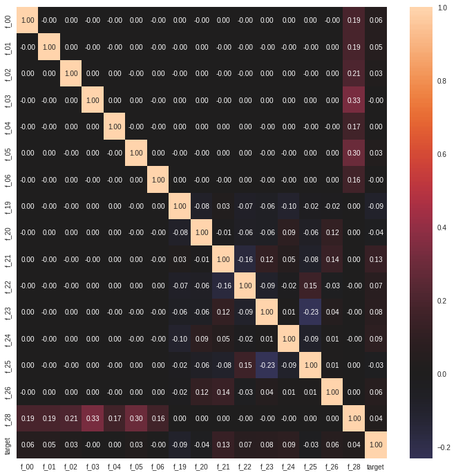

```python
plt.figure(figsize=(12, 12))
sns.heatmap(train[numeric + ['target']].corr(), center=0, annot=True, fmt='.2f')
plt.show()
```

A primera vista no hi ha forta correlació entre cap feature.

Grafiquem la densitat del *target* en un pla en funció de 2 *features* o combinació de features:

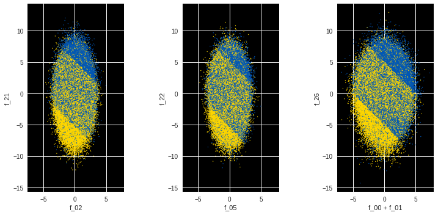

```python
plt.rcParams['axes.facecolor'] = 'k'
plt.figure(figsize=(11, 5))
import matplotlib
cmap = matplotlib.colors.ListedColormap(["#ffd700", "#0057b8"])
# target == 0 → yellow; target == 1 → blue

ax = plt.subplot(1, 3, 1)
ax.scatter(train['f_02'], train['f_21'], s=1,
           c=train.target, cmap=cmap)
ax.set_xlabel('f_02')
ax.set_ylabel('f_21')
ax.set_aspect('equal')
ax0 = ax

ax = plt.subplot(1, 3, 2, sharex=ax0, sharey=ax0)
ax.scatter(train['f_05'], train['f_22'], s=1,
           c=train.target, cmap=cmap)
ax.set_xlabel('f_05')
ax.set_ylabel('f_22')
ax.set_aspect('equal')

ax = plt.subplot(1, 3, 3, sharex=ax0, sharey=ax0)
ax.scatter(train['f_00'] + train['f_01'], train['f_26'], s=1,
           c=train.target, cmap=cmap)
ax.set_xlabel('f_00 + f_01')
ax.set_ylabel('f_26')
ax.set_aspect('equal')

plt.tight_layout(w_pad=1.0)
#plt.savefig('projeccions.png')
plt.show()
plt.rcParams['axes.facecolor'] = '#0057b8' # blue
```

En groc targets 0, en blau targets 1

Visualitzant combinacions de features en 2D i especificament en aquestes 3 combinacions, es troben 3 regions ben diferenciades on la densitat de targets de la mateixa classe és uniforme. Aquestes regions estàn separades linealment per una combinació de features.

Si afegim una *feature* amb informació sobre a quina de les 3 regions pertany cada instància ajudarem a la xarxa neuronal a realitzar la classificació.

- Si la instància es troba a la regió de dalt a la dreta, la probabilitat que el target==1 es alta -->1.
- Si la instància es troba a la regió del mig, la probabilitat que el target==1 es similar a sigui 0-->0.
- Si la instància es troba a la regió de baix, a l'esquerra la probabilitat que el target==1 es baixa -->-1.

Afegim informació de la regió a que pertany cada instància en els 3 espais 2D:

```python
for df in [X_trainval]:
    df['i_02_21'] = (df.f_21 + df.f_02 > 5.2).astype(int) - (df.f_21 + df.f_02 < -5.3).astype(int)
    df['i_05_22'] = (df.f_22 + df.f_05 > 5.1).astype(int) - (df.f_22 + df.f_05 < -5.4).astype(int)
    i_00_01_26 = df.f_00 + df.f_01 + df.f_26
    df['i_00_01_26'] = (i_00_01_26 > 5.0).astype(int) - (i_00_01_26 < -5.0).astype(int)
```

```python
print(X_trainval.shape)
print(X_trainval.columns)
```

```
(900000, 33)
Index(['f_00', 'f_01', 'f_02', 'f_03', 'f_04', 'f_05', 'f_06', 'f_07', 'f_08',
       'f_09', 'f_10', 'f_11', 'f_12', 'f_13', 'f_14', 'f_15', 'f_16', 'f_17',
       'f_18', 'f_19', 'f_20', 'f_21', 'f_22', 'f_23', 'f_24', 'f_25', 'f_26',
       'f_28', 'f_29', 'f_30', 'i_02_21', 'i_05_22', 'i_00_01_26'],
      dtype='object')
```

Afegim la nova informació:

```python
X_total=np.hstack((X_num, X_cat,f_27_dummy,unic_ch_dummy,np.array(X_trainval[['i_02_21','i_05_22','i_00_01_26']])))#np.column_stack()
print(X_total.shape)
```

```
(900000, 300)
```

```python
X_nn=X_total[:810000,:]
print(X_nn.shape)
X_validate=X_total[810000:,:]
print(X_validate.shape)
"Target"
y=train['target'].copy()
y=np.array(y)
```

```
(810000, 300)
(90000, 300)
```

# Final Neural Network

Tornem a dissenyar i fer proves amb la xarxa neuronal:

```python
model = keras.Sequential()
model.add(layers.Dense(64, activation='relu',kernel_initializer='normal', input_shape = (X_nn.shape[1],)))
model.add(BatchNormalization())
model.add(layers.Dense(64, activation='relu',kernel_initializer='normal'))
model.add(BatchNormalization())
model.add(layers.Dense(64, activation='relu',kernel_initializer='normal'))
model.add(BatchNormalization())
model.add(layers.Dense(64, activation='relu',kernel_initializer='normal'))
model.add(BatchNormalization())
model.add(layers.Dense(40, activation='relu',kernel_initializer='normal'))
model.add(BatchNormalization())
model.add(layers.Dense(20, activation='relu',kernel_initializer='normal'))
model.add(BatchNormalization())
model.add(layers.Dense(1, activation='sigmoid'))

opt = keras.optimizers.Adam(learning_rate=0.03)
model.compile(optimizer=opt, loss='binary_crossentropy',metrics=['accuracy'])
```

```python
from tensorflow.keras.utils import plot_model
```

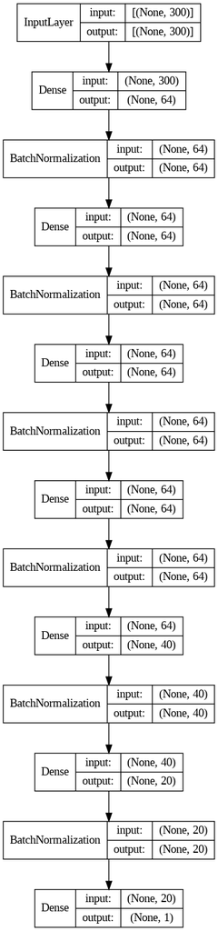

```python
plot_model(model, show_layer_names=False, show_shapes=True)
```

```python
with tf.device('/GPU:0'):
    history2 = model.fit(X_nn, y, validation_split=0.1, batch_size=512, epochs=300, \
                        callbacks =EarlyStopping(monitor='val_loss',patience=5))
```

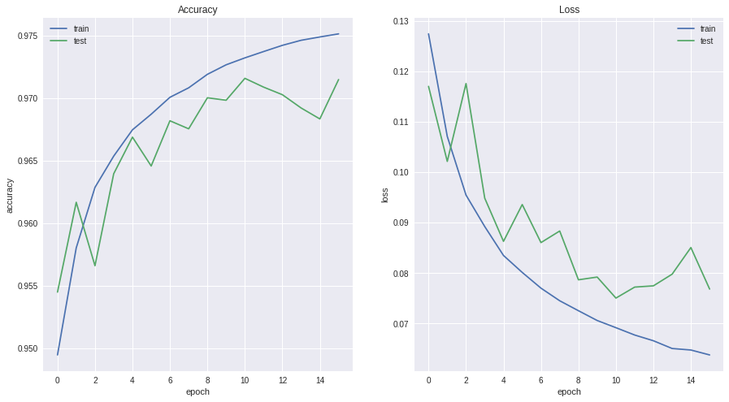

```python
plt.style.use('seaborn')
fig, (ax1, ax2) = plt.subplots(1,2,figsize=(15,8))

#Accuracy
ax1.plot(history2.history['accuracy'], label='train')
ax1.plot(history2.history['val_accuracy'], label='test')
ax1.set_xlabel('epoch')
ax1.set_ylabel('accuracy')
ax1.set_title('Accuracy')
ax1.legend()

#Loss
ax2.plot(history2.history['loss'], label='train')
ax2.plot(history2.history['val_loss'], label='test')
ax2.set_xlabel('epoch')
ax2.set_ylabel('loss')
ax2.set_title('Loss')
ax2.legend()
plt.show()
```

# Exportació de la solució

```python
y_prob = model.predict(X_validate)
y_class = [int(i > .5) for i in y_prob]
solution=pd.DataFrame()
solution['target']=y_class
print(solution.target.value_counts())
solution['id']=validate.id
solution=solution.set_index('id')
print(solution.shape)
solution.head()
solution.to_csv('nn.csv')
```

```
0    45870
1    44130
Name: target, dtype: int64
(90000, 1)
```